# Practical Machine Learning Assignment

Camilo Dorado

#### Introduction

In this work we pretend to apply some routines of the R packages *randomForest* and *caret*, to a problem of classification. Then we create a training dataset with 60% of total data. Based on subsamples of the training dataset, we build, train and evaluate several random forest models, using cross-validation as the first approach to decide if principal components pre-processing is or not necessary to achieve a better accuracy. Finally, we construct a final random forest model based in the totality of training dataset, and confirm the expected error rates.

#### Data acquisition

Data were downloaded from https://d396qusza40orc.cloudfront.net/predmachlearn/pml-training.csv on Sun Oct 25 21:10:10 2015.

#### Cross-validation

60% of the data set was used to build and evaluate the models, and the other 40% was left to validate the obtained results. Ten times, we sample a 60% of the training dataset in order to build a random forest model, with and without principal components pre-processing. The accuracy obtained for each model in the other 40% of the training dataset, was saved for each random forest model.

```r
set.seed(20151025)
#Create a data partition and reserve the test dataset to assess the out-of-bag error
inTrain <- createDataPartition(y=training$classe, p=0.6, list=F)
train <- training[inTrain,]
test <- training[-inTrain,]

#Perform 10 simulations to compare the random forests algorithms with and without PCA
#pre-processing
nSimulations <- 10
results <- data.frame(accuracy=NA, pValue=NA, accuracyPCA=NA, pValuePCA=NA)

for(sim in 1:nSimulations){
  #For each simulation, generate a partition to train and test the models
  trainIndex <- createDataPartition(train$classe, p=0.60, list=F)
  trainSimulation <- train[trainIndex,]
  testSimulation <- train[-trainIndex,]
  #Create a random forest model with the partial training dataset
  rForestModel <- randomForest(classe ~ ., data=trainSimulation)
  #Predict for the partial testing dataset
  predictionRandomForest <- predict(rForestModel, testSimulation)
  #Save the accuracy of the prediction and its associated p-value the results dataframe
  results[sim, c("accuracy", "pValue")] <-
    confusionMatrix(predictionRandomForest, testSimulation$classe)$overall[c(1, 6)]
  #For the same partition, create a random forest model with the partial training dataset
  #and pre-process with principal components analysis
  rForestModelPCA <- randomForest(classe ~ ., data=trainSimulation,
                          preProcess="pca")
  #Predict for the partial testing dataset
  predictionRandomForestPCA <- predict(rForestModelPCA, testSimulation)
  #Save the accuracy of the prediction and its associated p-value the results dataframe
  results[sim, c("accuracyPCA", "pValuePCA")] <-
   confusionMatrix(predictionRandomForestPCA, testSimulation$classe)$overall[c(1, 6)]
  }
```

#### Cross-validation results

Comparing the mean and standard deviation of error measures (proportion of incorrectly classified observations in each simulation) for the random forest models with and without PCA pre-processing, the advantage of pre-processing is not evident. Both kind of models perform really well in classification (p-value associated with accuracy is ever less than 0.001).

```r
#Collect the mean and sd of error rates (1 - accuracy) for each kind of model
meanErrorRate <- mean(1 - results$accuracy)
sdErrorRate <- sd(1 - results$accuracy)
meanErrorRatePCA <- mean(1 - results$accuracyPCA)
sdErrorRatePCA <- sd(1 - results$accuracyPCA)
#Count the number of simulations when the PCA pre-processed random forest outperform the
#non-pre-processed one
sum(results$accuracyPCA>results$accuracy)
```

```
## [1] 2
```

We choose a model without PCA pre-processing, which gives error rates between 1.1% and 1.4% in the 10 simulations performed (mean = 1.2%, SD = 0.2%).

#### Final model and evaluation

```r
finalModel <- randomForest(classe ~ ., data=train)
prediction <- predict(finalModel, test)
confusionMatrix <- confusionMatrix(prediction, test$classe)
```

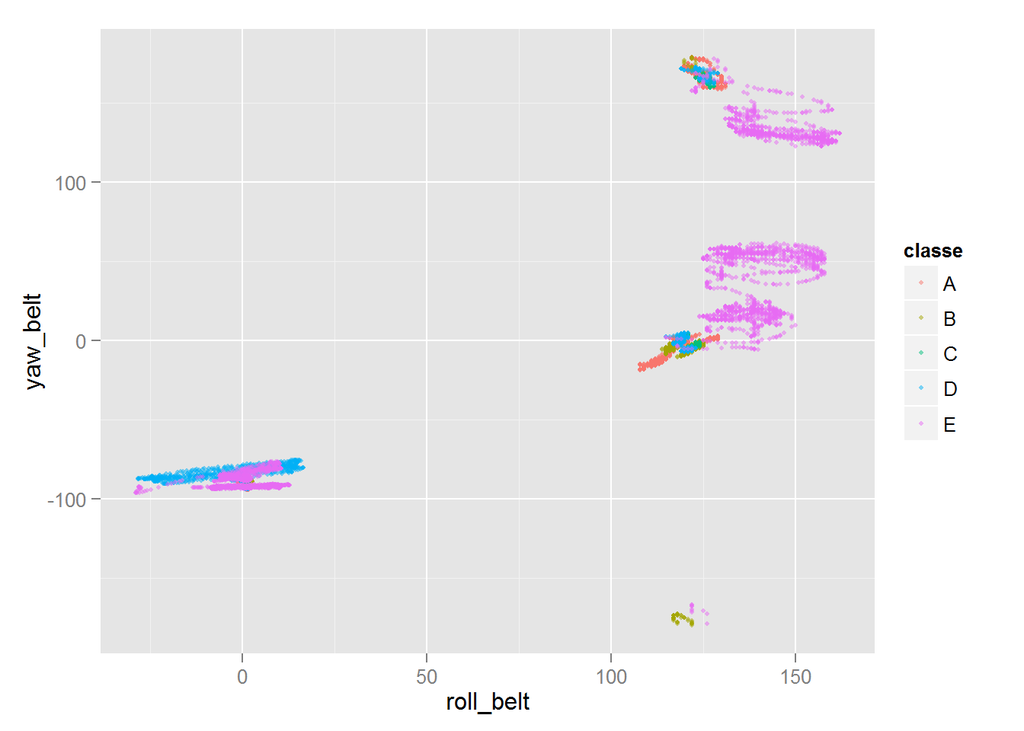

```r
library(ggplot2)
#Find the five most important variables
mainVars <- head(names(train)[order(finalModel$importance, decreasing=TRUE)], 5)
#Plot every data colored by classe
ggplot(aes_string(x=mainVars[1], y=mainVars[2], colour="classe"), data=training) +
  geom_point(alpha=0.5, size=1)
```

#### Performance in the classification task

Finally, we use the given obtained random forest model to solve the assigned classification task.

```r
answers <- predict(finalModel, testing)
print(answers)
```

```
##  1  2  3  4  5  6  7  8  9 10 11 12 13 14 15 16 17 18 19 20
##  B  A  B  A  A  E  D  B  A  A  B  C  B  A  E  E  A  B  B  B
## Levels: A B C D E
```